# Cancer in Scotland

Lesley Duff

2023-10-19

# Overview

## Data Quality

https://www.nrscotland.gov.uk/statistics-and-data/statistics/statistics-by-theme/vital-events/deaths/deaths-background-information/quality-of-nrs-data-on-deaths

# Death

## Background

We wish to see where cancer fits into the overall pattern of death in Scotland. The [National Records of Scotland](https://www.nrscotland.gov.uk/) (NRS) maintain official death statistics for Scotland. This analysis utilises NRS data.

When a death is registered, it is common for a number of diseases or conditions to be recorded on the death certificate. NRS apply the WHO rules to determine which of these conditions is the underlying cause of death.” - [Death Certificates and Coding the Causes of Death](https://www.nrscotland.gov.uk/statistics-and-data/statistics/statistics-by-theme/vital-events/deaths/deaths-background-information/death-certificates-and-coding-the-causes-of-death)

**Source:**  
[Table 1: All ages age-standardised death rates for all causes and certain selected causes, Scotland, 1994 to 2022](https://www.nrscotland.gov.uk/statistics-and-data/statistics/statistics-by-theme/vital-events/deaths/age-standardised-death-rates-calculated-using-the-esp).  
NRS Last update: 19 September 2023.

Definition: `rate` is deaths per 100,000 people in Scotland using. The NRS data is age-standardised using the European Standard Population.

There are **13** categories of causes recorded in the dataset.

```
##  [1] "Accidents"
##  [2] "Alcohol-specific"
##  [3] "All causes"
##  [4] "Cancer (malignant neoplasms: 140-208 /C00-97)"
##  [5] "Cerebrovascular disease (stroke:430-438 / I60-69)"
##  [6] "Chronic Obstructive Pulmonary Disease NEW DEF(490-492,496 / J40-44)"
##  [7] "Covid-19"
##  [8] "Dementia and Alzheimer's"
##  [9] "Diseases of the circulatory system(390-459 / I00-I99)"
## [10] "Diseases of the respiratory system(460-519 / J00-99)"
## [11] "drug related"
## [12] "Ischaemic (coronary) heart disease(410-414 / I20-25)"
## [13] "Probable suicide"
```

As you can see these are formal technical names. For simplifying ongoing work the following substitutions have been made and called `cause_simple`.

```
##  [1] "Accidents"                "Alcohol-specific"
##  [3] "All causes"               "Cancer"
##  [5] "Cerebrovascular disease"  "Circulatory"
##  [7] "COVID-19"                 "Dementia and Alzheimer's"
##  [9] "Drug related"             "Heart"
## [11] "Probable suicide"         "Pulmonary (COPD)"
## [13] "Respiratory"
```

## Analysis

### How does death from cancer in Scotland compare to other causes?

#### Overview

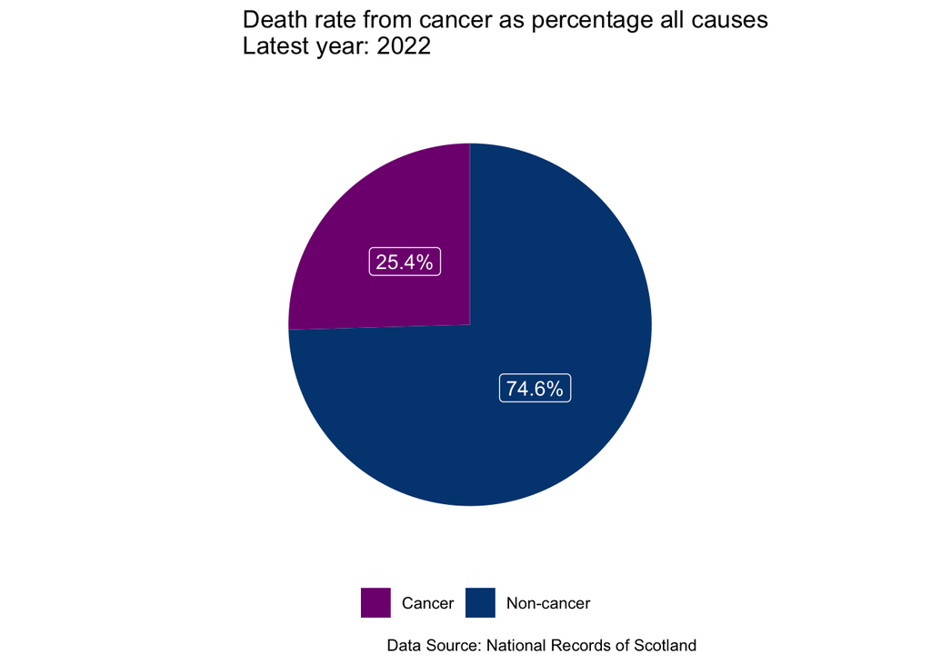

This shows the proportion of deaths from cancer compared to all other causes combined for the most recently available year of data - 2022.

At time of writing cancer accounts for almost exactly a quarter of all deaths.

#### Change over time for all causes of death

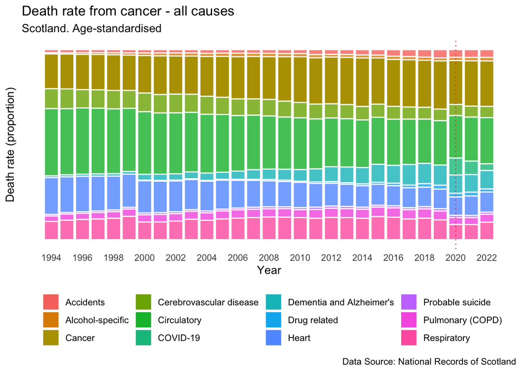

This shows how the **proportion** of deaths is changing over time by cause.  
Cancer is the thirds bar from the top. A dotted red vertical line marks 2020 -the start of the COVID-19 pandemic. After 2020 many other non-COVID-19 conditions are once again worsening, however, **the rate of cancer deaths is improving**, albeit in a very small way. You can see this in the precise numbers if you filter the following table by ‘Cancer’.

N.B. This **does not** show changes in *amount*. What it does show is the relationship between all possible causes. If a particular cause bar is getting larger like dementia it is becoming worse or if it is decreasing like circulatory then people are becoming less likely to die from that cause.

For the latter it would indicate change in that a condition that people used to die of more in the past they’re now dying of *something else* instead, so in those cases it’s the ‘something else’ that has worsened and would be the things to take especial note of and investigate further.

A good example is the emergence in 2020 of COVID-19. People were dying from this new cause instead of the kind of thing they would normally have died of, including cancer. People with cancer and due to certain treatments can have weaker immune systems and be more vulnerable to disease. The bar for cancer certainly seems to shrink more than other causes in 2020. A further suggestion would be to investigate if more people with Cancer and/or Respitory were more likely to die if they subsequently caught COVID.

And another interpretation can be that treatments other factors are improving things. e.g. we might comment that things lke circulatory/heart/cerebrovascular disease have improved over the long term considerably since the start of the data in 1994 - could this be an example of improved emphasis on preventative work treating things like e.g. High Blood Pressure with medication and lifestyle changes? Is so, that would be an encouraging example that change is possible.

#### Table: Rate of death compared to other causes by year

**Tip:** To filter by a particular condition type in the ‘Search’ box.

|  | year | rate | cause_simple |
| --- | --- | --- | --- |
| 1 | 2022 | 1171.2 | All causes |
| 2 | 2022 | 302.4 | Circulatory |
| 3 | 2022 | 298 | Cancer |
| 4 | 2022 | 131.4 | Heart |
| 5 | 2022 | 121.2 | Dementia and Alzheimer's |
| 6 | 2022 | 114.5 | Respiratory |
| 7 | 2022 | 73.1 | Cerebrovascular disease |
| 8 | 2022 | 52 | Pulmonary (COPD) |
| 9 | 2022 | 50.6 | Accidents |
| 10 | 2022 | 43.6 | COVID-19 |

[output cut: 335 more lines]

#### Recent change in rate

|  | year | rate | cause_simple | rate_previous | rate_change | rate_change_pct |
| --- | --- | --- | --- | --- | --- | --- |
| 1 | 2022 | 1171.2 | All causes | 1180.6 | -9.4 | -0.8 |
| 2 | 2022 | 302.4 | Circulatory | 293 | 9.4 | 3.1 |
| 3 | 2022 | 298 | Cancer | 301.1 | -3.1 | -1 |
| 4 | 2022 | 131.4 | Heart | 129.7 | 1.7 | 1.3 |
| 5 | 2022 | 121.2 | Dementia and Alzheimer's | 116.9 | 4.3 | 3.5 |
| 6 | 2022 | 114.5 | Respiratory | 100.6 | 13.9 | 12.1 |
| 7 | 2022 | 73.1 | Cerebrovascular disease | 72.1 | 1 | 1.4 |
| 8 | 2022 | 52 | Pulmonary (COPD) | 46 | 6 | 11.5 |
| 9 | 2022 | 50.6 | Accidents | 51.7 | -1.1 | -2.2 |
| 10 | 2022 | 43.6 | COVID-19 | 89.4 | -45.8 | -105 |

[output cut: 3 more lines]

##### Improving since previous year available - 2021

These are what got ‘better’ in terms of death rate between the latest two years of data.

|  | cause_simple | rate_change_pct |
| --- | --- | --- |
| 1 | COVID-19 | -105 |
| 2 | Drug related | -26.3 |
| 3 | Accidents | -2.2 |
| 4 | Cancer | -1 |
| 5 | All causes | -0.8 |

Conclusion: **rates of cancer deaths have improved for the most recent year**.

It’s not possible to tell from our data whether any of the screening or vacination programmes contribute in any way to the improvement. And the improvement is so small it’s almost static.

Of interest is that in spite of a great deal of negative publicity about Scottish drug related deaths being worse than many other countries there *has* been an improvement in *rates* recently.

##### Worsening since previous year available - 2021

Ordered by greatest percentage change (worst) to least.

|  | cause_simple | rate_change_pct |
| --- | --- | --- |
| 1 | Respiratory | 12.1 |
| 2 | Pulmonary (COPD) | 11.5 |
| 3 | Dementia and Alzheimer's | 3.5 |
| 4 | Circulatory | 3.1 |
| 5 | Alcohol-specific | 2.6 |
| 6 | Cerebrovascular disease | 1.4 |
| 7 | Probable suicide | 1.4 |
| 8 | Heart | 1.3 |

This category includes things like flu and pneumonia. There is a flu vacination programme in Scotland, do they have more data available that could be checked?

**Conclusion: Respiratory conditions have worsened the most**.

Keep an eye on issues relating to Respiratory and Pulmanary as these worsened the most in the last two years.

**Conclusion: Preventable causes of death like alcohol and suicide have risen**.

More work needs to be done to target these.

# Incidence

## Background

There are *multiple* different types of cancer. We would like to find out which types have been recorded in Scotland and how these have changed over time.

Different cancers are categorised (coded) according to World Health Organisation (WHO) [International Statistical Classification of Diseases and Related Health Problems (ICD)](https://www.who.int/standards/classifications/classification-of-diseases). In Scotland, currently the ‘ICD-10’ code is used when a patient is diagnosed to record which type of cancer they have. Example of an ICD-10 code: C50 = ‘Breast’ cancer.

### Terminology

Technical terms used relating to this dataset.

| Term | Description |
| --- | --- |
| **incidence** | The total number of new cases (registrations) of the cancer diagnosed in Scotland for the given period. |
| **cancer site** | The place where a cancer starts in the body. This is represented as a code and also a human readable name |

The [Scottish Cancer Registry and Intelligence Service](https://publichealthscotland.scot/our-areas-of-work/conditions-and-diseases/cancer/scottish-cancer-registry-and-intelligence-service-scris/overview/) (SCRIS) collects detailed information on every cancer in Scotland. However, this raw information is **not public** and can only be directly accessed by people in the NHS and approved individuals.

Public Health Scotland (PHS) makes available extracts from the SCRIS as open data. For this analysis the [Annual Cancer Incidence](https://www.opendata.nhs.scot/dataset/annual-cancer-incidence) data will be used. Specifically [Incidence at Scotland Level](https://www.opendata.nhs.scot/dataset/annual-cancer-incidence/resource/72c852b8-ee28-4fd8-84a9-5f415f4bc325). Annual number and rate of new cancer registrations in Scotland by sex and age.

Cancer incidence in Scotland To December 2021)

The following dataset gives us an annual number and rate of new cancer registrations in Scotland by sex and age. Reports include data from 1997 to 2021.

**Source:** [Incidence at Scotland Level](https://www.opendata.nhs.scot/dataset/c2c59eb1-3aff-48d2-9e9c-60ca8605431d/resource/72c852b8-ee28-4fd8-84a9-5f415f4bc325/download/opendata_inc9721_scotland.csv). PHS Last update: 29 March 2023.

This analysis utilises PHS data.

### Important! When is a medical cancer a ‘cancer’ in official reports?

“‘All cancers’ by convention **excludes non-melanoma skin cancers**.” - PHS.

Non-melanoma skin cancers are in the original open data supplied. To keep consistent with the official reporting standard ‘Non-melanoma skin cancers’ have been excluded from this analysis. -  
[Cancer incidence in Scotland To December 2021](https://publichealthscotland.scot/publications/cancer-incidence-in-scotland/cancer-incidence-in-scotland-to-december-2021/)

## Analysis

This dataset is since 1997.

### Time: Cancer Incidences by Year and Sex

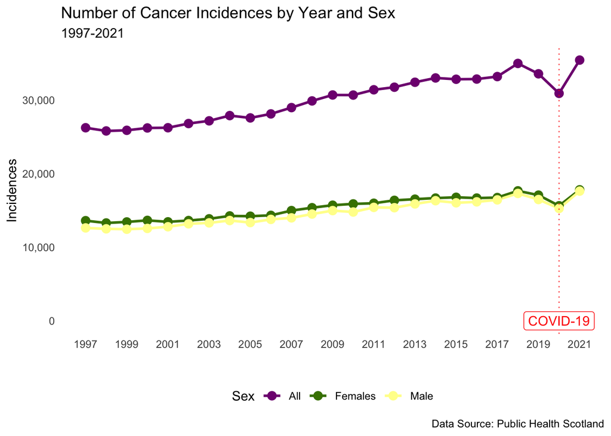

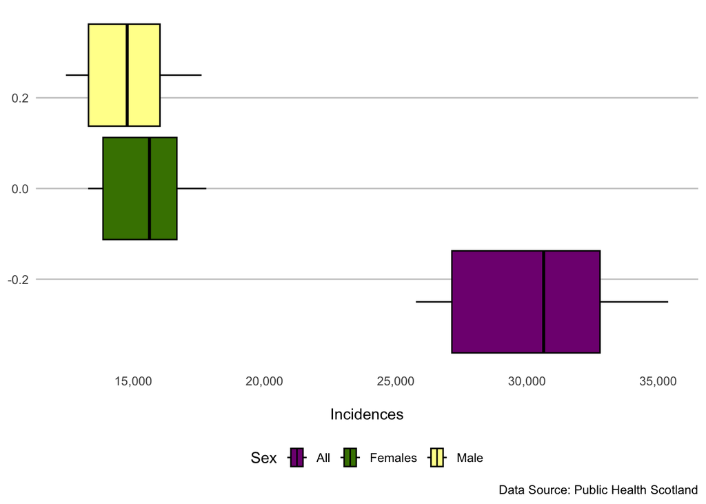

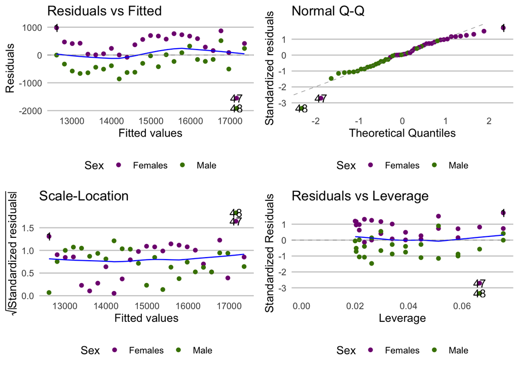

Years with highest/lowest cancer incidences

Data between: 1997 and 2021

| Result | Incidences | Year |
| --- | --- | --- |
| Highest | 35,379 | 2021 |
| Lowest | 12,432 | 1999 |

Data Source: Public Health Scotland

Cancer incidences had been steadily increasing since the late 1990s before starting to drop in 2019, note this was the year *before* COVID-19 started. Unfortunately the most recent year of data the cases are at their highest number ever. This has to be caveated with our growing and ageing population. So the drop on the year of COVID-19 itself might have been part of an already decreasing trend. There was widespread disruption to health services and daily life. All manner of primary care (e.g. GP practices) and diagnostic services were interrupted completely or on heavily reduced capacity which may give some administrative reasons for a drop in formal diagnoses. The steep rise 2020-2021 may have part of a backlog of cases as part of that increase.

GPs commented at the time that a lot of patients weren’t coming to them. they are often the first point of contact for those with symptoms/concerns eventually leading to a formal cancer diagnosis. [“GPs are worried about “missing patients” and the backlog which has built up in chronic disease management, screening, immunisation and cancer referrals.” DEEP END REPORT 36 General Practice in the time of Covid-19](https://www.gla.ac.uk/media/Media_728030_smxx.pdf) June 2020.

People with weak immune systems were more vulnerable to negative outcomes from the virus and the elderly being more likely to die from COVID-19 may also have had the side effect of reducing the number of old people with a diagnosis of a new case of cancer. This is probably the sort of question that might be able to be tested by those with access to the Scottish Cancer Registry to track patients with other multiple conditions.

### Types of Cancer (Cancer Sites)

#### Abbreviations for charts

Some of the names of the cancers are rather long. To help make these more legible on charts the following substitutions have been made. If you see “…” next to a name it means it’s been adjusted to use the names in the following table.

Abbreviations for Cancer Site names

| Short Name | Cancer Site |
| --- | --- |
| ALL... | Acute lymphoblastic leukaemia |
| AML | Acute myeloid leukaemia |
| Bone & A... | Bone and articular cartilage |
| Bone & C... | Bone and connective tissue |
| Brain | Malignant brain cancer |
| Brain & CNS... | All brain and CNS tumours (malignant and non-malignant) |
| Brain incl... | Malig brain ca (incl pit. gland, cranio. duct, pineal gland) |
| CLL... | Chronic lymphocytic leukaemia |
| CML... | Chronic myeloid leukaemia |
| Colorectal... | Colorectal cancer |
| Connective... | Connective tissue |
| Head... | Head and neck |
| Hodgkin... | Hodgkin lymphoma |
| Lip/Oral... | Lip, oral cavity and pharynx |
| Liver & bile... | Liver and intrahepatic bile ducts |
| Lung... | Trachea, bronchus and lung |
| Mouth... | Mouth (IARC definition) |
| Myeloma... | Multiple myeloma and malignant plasma cell neoplasms |
| Non-Hodgkin... | Non-Hodgkin lymphoma |
| Oropharyngeal... | Oropharyngeal cancers |
| Rectum... | Rectum and rectosigmoid junction |
| Salivary... | Salivary glands |
| Skin... | Malignant melanoma of the skin |

#### Incidences by Year and Cancer Sites

In Scotland cancers are categorised (coded) to World Health Organisation standards.

Here are the **recorded*** cancers for the all the years available (1997-2021) in the dataset.

There are **45** types of cancer (cancer sites).

These represent multiple years and all ages and sexes.  
* Some excluded from all cancer reporting e.g. non-malignant skin cancer.

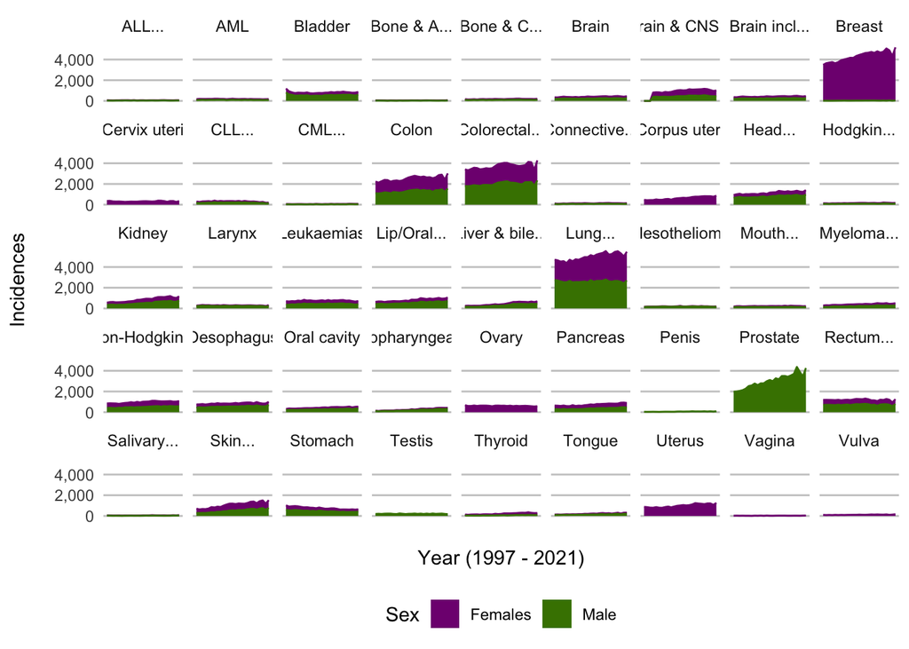

##### All time (1997-2021)

Cancer Sites in Scotland

Between: 1997 and 2021

| Cancer Site | Average | Total |
| --- | --- | --- |
| Trachea, bronchus and lung | 2,504 | 125,189 |
| Breast | 2,159 | 107,964 |
| Colorectal cancer | 1,863 | 93,160 |
| Prostate | 3,027 | 75,673 |
| Colon | 1,267 | 63,337 |
| Rectum and rectosigmoid junction | 596 | 29,823 |
| Head and neck | 576 | 28,792 |
| Malignant melanoma of the skin | 538 | 26,912 |
| Uterus | 1,000 | 24,988 |
| Non-Hodgkin lymphoma | 487 | 24,345 |
| All brain and CNS tumours (malignant and non-malignant) | 436 | 21,788 |
| Kidney | 431 | 21,561 |
| Oesophagus | 426 | 21,314 |
| Bladder | 412 | 20,622 |
| Lip, oral cavity and pharynx | 409 | 20,444 |
| Stomach | 382 | 19,119 |
| Leukaemias | 373 | 18,651 |
| Pancreas | 366 | 18,290 |
| Corpus uteri | 631 | 15,779 |
| Ovary | 611 | 15,273 |
| Liver and intrahepatic bile ducts | 225 | 11,227 |
| Oral cavity | 218 | 10,898 |
| Malig brain ca (incl pit. gland, cranio. duct, pineal gland) | 212 | 10,581 |
| Malignant brain cancer | 203 | 10,149 |
| Multiple myeloma and malignant plasma cell neoplasms | 202 | 10,095 |
| Cervix uteri | 320 | 7,993 |
| Chronic lymphocytic leukaemia | 154 | 7,706 |
| Larynx | 147 | 7,333 |
| Oropharyngeal cancers | 134 | 6,714 |
| Mouth (IARC definition) | 112 | 5,598 |
| Thyroid | 108 | 5,390 |
| Tongue | 106 | 5,300 |
| Testis | 205 | 5,117 |
| Mesothelioma | 98 | 4,876 |
| Acute myeloid leukaemia | 92 | 4,577 |
| Bone and connective tissue | 89 | 4,466 |
| Hodgkin lymphoma | 77 | 3,852 |
| Connective tissue | 66 | 3,286 |
| Vulva | 114 | 2,842 |
| Acute lymphoblastic leukaemia | 31 | 1,548 |
| Chronic myeloid leukaemia | 30 | 1,498 |
| Penis | 56 | 1,399 |
| Salivary glands | 26 | 1,285 |
| Bone and articular cartilage | 24 | 1,180 |
| Vagina | 24 | 601 |

Data Source: Public Health Scotland

##### Most recent year available (2021)

For comparison here is the list only for the latest year of data.

Cancer Sites in Scotland

2021

| Cancer Site | Total |
| --- | --- |
| Trachea, bronchus and lung | 5,476 |
| Breast | 5,180 |
| Colorectal cancer | 4,279 |
| Prostate | 4,265 |
| Colon | 3,023 |
| Malignant melanoma of the skin | 1,525 |
| Head and neck | 1,400 |
| Rectum and rectosigmoid junction | 1,256 |
| Uterus | 1,254 |
| Kidney | 1,162 |
| Non-Hodgkin lymphoma | 1,067 |
| Lip, oral cavity and pharynx | 1,045 |
| All brain and CNS tumours (malignant and non-malignant) | 1,006 |
| Oesophagus | 997 |
| Pancreas | 887 |
| Bladder | 863 |
| Corpus uteri | 860 |
| Leukaemias | 713 |
| Liver and intrahepatic bile ducts | 686 |
| Stomach | 641 |
| Ovary | 576 |
| Oral cavity | 538 |
| Multiple myeloma and malignant plasma cell neoplasms | 503 |
| Malig brain ca (incl pit. gland, cranio. duct, pineal gland) | 468 |
| Malignant brain cancer | 451 |
| Oropharyngeal cancers | 422 |
| Cervix uteri | 342 |
| Tongue | 319 |
| Larynx | 313 |
| Thyroid | 281 |
| Mouth (IARC definition) | 219 |
| Bone and connective tissue | 209 |
| Chronic lymphocytic leukaemia | 197 |
| Mesothelioma | 195 |
| Acute myeloid leukaemia | 172 |
| Hodgkin lymphoma | 170 |
| Testis | 166 |
| Vulva | 163 |
| Connective tissue | 142 |
| Penis | 86 |
| Salivary glands | 80 |
| Chronic myeloid leukaemia | 72 |
| Bone and articular cartilage | 67 |
| Acute lymphoblastic leukaemia | 66 |
| Vagina | 36 |

Data Source: Public Health Scotland

### Age Range

What age are people when they are newly diagnosed. Would knowing the demographics of different diseases affect what kind of public health information and awareness raising needs to be done?

### Top Incidences by Cancer Site, Age Group and Sex

This is a list of those cancer sites, age groups and sexes most at risk of having a new cancer diagnosed.

Top 10 All

| Cancer Site | Age Range | Sex | Incidences |
| --- | --- | --- | --- |
| Prostate | 70-74 | Male | 300,732 |
| Prostate | 65-69 | Male | 280,022 |
| Breast | 50-54 | Females | 257,488 |
| Breast | 60-64 | Females | 256,823 |
| Prostate | 75-79 | Male | 252,225 |
| Breast | 65-69 | Females | 249,318 |
| Trachea, bronchus and lung | 70-74 | Male | 245,309 |
| Breast | 55-59 | Females | 234,992 |
| Trachea, bronchus and lung | 75-79 | Male | 226,176 |
| Trachea, bronchus and lung | 70-74 | Females | 211,394 |

Data Source: Public Health Scotland

Top 5 Female

| Cancer Site | Age Range | Sex | Incidences |
| --- | --- | --- | --- |
| Breast | 50-54 | Females | 257,488 |
| Breast | 60-64 | Females | 256,823 |
| Breast | 65-69 | Females | 249,318 |
| Breast | 55-59 | Females | 234,992 |
| Trachea, bronchus and lung | 70-74 | Females | 211,394 |

Data Source: Public Health Scotland

Top 5 Male

| Cancer Site | Age Range | Sex | Incidences |
| --- | --- | --- | --- |
| Prostate | 70-74 | Male | 300,732 |
| Prostate | 65-69 | Male | 280,022 |
| Prostate | 75-79 | Male | 252,225 |
| Trachea, bronchus and lung | 70-74 | Male | 245,309 |
| Trachea, bronchus and lung | 75-79 | Male | 226,176 |

Data Source: Public Health Scotland

Top 5 Females 20-29

| Cancer Site | Age Range | Sex | Incidences |
| --- | --- | --- | --- |
| Uterus | 25-29 | Females | 12,293 |
| Cervix uteri | 25-29 | Females | 12,065 |
| Malignant melanoma of the skin | 25-29 | Females | 9,766 |
| Breast | 25-29 | Females | 6,726 |
| Malignant melanoma of the skin | 20-24 | Females | 6,118 |

Data Source: Public Health Scotland

Top 5 Male 20-29

| Cancer Site | Age Range | Sex | Incidences |
| --- | --- | --- | --- |
| Testis | 25-29 | Male | 14,554 |
| Testis | 20-24 | Male | 7,809 |
| Malignant melanoma of the skin | 25-29 | Male | 4,085 |
| All brain and CNS tumours (malignant and non-malignant) | 25-29 | Male | 3,800 |
| Hodgkin lymphoma | 25-29 | Male | 3,648 |

Data Source: Public Health Scotland

Top 5 Hodgkin lymphoma

| Cancer Site | Age Range | Sex | Incidences |
| --- | --- | --- | --- |
| Hodgkin lymphoma | 20-24 | Females | 3,648 |
| Hodgkin lymphoma | 25-29 | Male | 3,648 |
| Hodgkin lymphoma | 20-24 | Male | 3,553 |
| Hodgkin lymphoma | 40-44 | Male | 3,496 |
| Hodgkin lymphoma | 30-34 | Male | 3,477 |

Data Source: Public Health Scotland

#### Incidences by Age Range, Sex and Cancer Site

Here we have age-related data where incidences have been provided in 5-year categories from 0, .. to 90+. This data gives us the chance to consider the relationship between ageing and risk of being diagnosed with a new cancer.

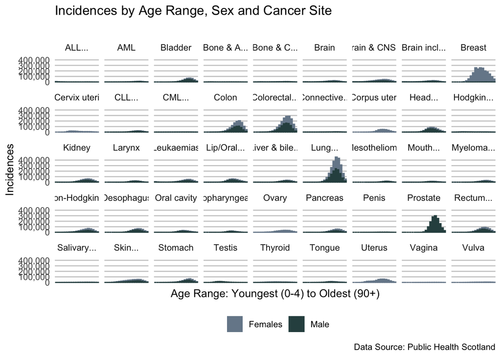

We see 4 main cancers dominating in terms of numbers Colorectal/Lung/Breast and prostate. The pattern over many cancers in terms of age range is that most of them really become much more prevalent from middle age onwards, peaking for new cases when we are in our 70s.

The ones that buck that trend tend to be the ones associates with female reproductive organs.

Suggestion: * Is the public aware of the increased risk simply by ageing? Are there opportunities to raise awareness among people engaging with other health or public sector organisations to be watchful for early symptoms.

- There are already screening programmes for breast/bowel and cervical cancer. Lung and Prostate cancer are some of the top in terms of numbers. Is there some equivalent of screening for these two in particular? If not, keep informed of any developments in early detection of these two.

TODO cleanup

# Screening

## Background

### Scottish Bowel Screening Programme

Commenced in 2007 with a full rollout across all health boards by 2009.

People aged 50-74 years are invited every two years to complete a home bowel screening test. 75 and over can self-refer.

### Uptake

The [Healthcare Improvement Scotland (HIS) standard target](https://www.healthcareimprovementscotland.org/our_work/standards_and_guidelines/stnds/bowel_screening_standards.aspx) for bowel screening is **uptake is 60%**.

Based on [Scottish bowel screening programme statistics For the period of invitations from May 2020 to April 2022](https://publichealthscotland.scot/publications/scottish-bowel-screening-programme-statistics/scottish-bowel-screening-programme-statistics-for-the-period-of-invitations-from-may-2020-to-april-2022/)

“The proportion of invites which are returned as a correctly completed kit (i.e. a positive or negative test result). It is a key measure of the acceptability of the test to the public.”

Health Improvement Scotland [Bowel screening standards: August 2023 (PDF)](https://www.healthcareimprovementscotland.org/his/idoc.ashx?docid=49b039aa-f6cf-42aa-8fda-3d6bc165bd21&version=-1).

## Analysis

### All Scotland

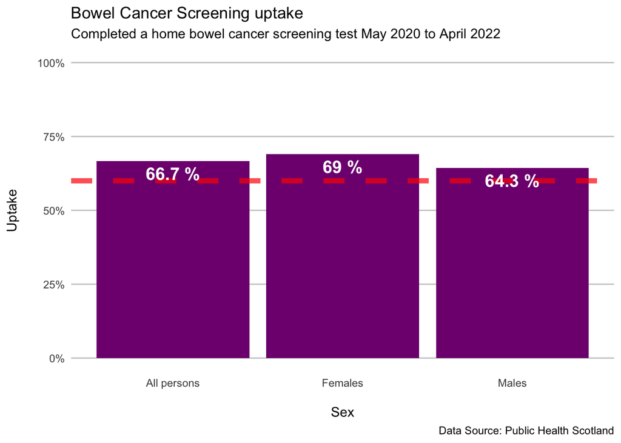

The red dashed horizontal line marks the Health Improvement Scotland standard **target of 60%**.

This shows that in the current Bowel Cancer Screening latest results around 2/3 of the people invited via the screening programme are taking up the offer.

Females are more likely to return the tests than males.

Bowel Cancer Screening Uptake

Data for May 2020 to April 2022

| Sex | Health Board | Uptake (%) |
| --- | --- | --- |
| All persons | Scotland | 66.7 |
| Females | Scotland | 69.1 |
| Males | Scotland | 64.3 |

Data Source: Public Health Scotland

For the most recent round of testing the target has been met and exceeded by a clear margin.

Continue to enhance communication to try and engage the remaining third of the general public making more efforts to target males.

**Conclusion: 60% target is being met but room for improvement**.

### All Uptake by Health Board and Sex

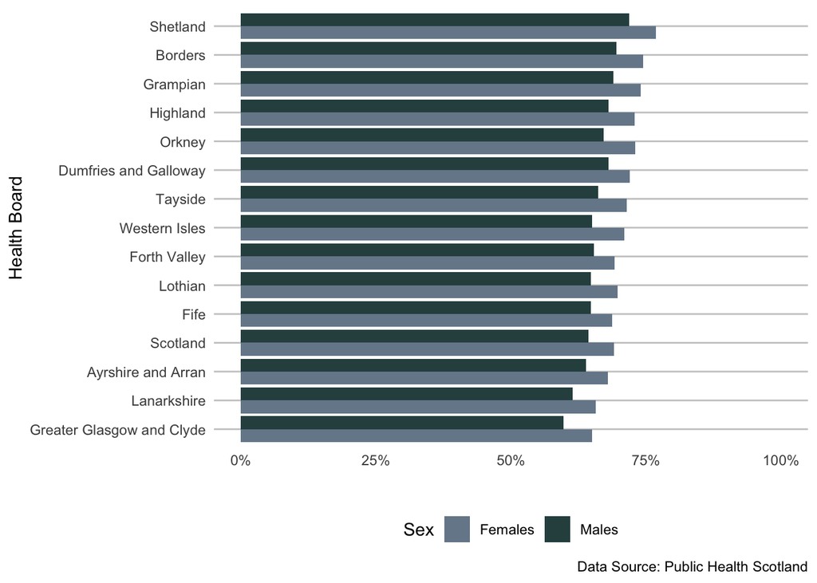

Females return their testing kits more than males for every Health Board in Scotland.

Just to confirm the numbers for each Health Board the following table is ordered by those with the lowest uptake first.

Bowel Cancer Screening Uptake

Data for May 2020 to April 2022

| Sex | Health Board | Uptake (%) |
| --- | --- | --- |
| All persons | Greater Glasgow and Clyde | 62.4 |
| All persons | Lanarkshire | 63.6 |
| All persons | Ayrshire and Arran | 66.0 |
| All persons | Fife | 66.8 |
| All persons | Lothian | 67.3 |
| All persons | Forth Valley | 67.3 |
| All persons | Western Isles | 67.9 |
| All persons | Tayside | 68.8 |
| All persons | Dumfries and Galloway | 70.1 |
| All persons | Orkney | 70.1 |
| All persons | Highland | 70.5 |
| All persons | Grampian | 71.5 |
| All persons | Borders | 72.0 |
| All persons | Shetland | 74.3 |

Data Source: Public Health Scotland

- Highest: Shetland (74.3%)
- Lowest: Greater Glasgow and Clyde (62.4%)

There is almost 12% difference between the highest and lowest uptakes between health boards, this seems seems relatively large. In general, the further the health board is from the Central Belt of Scotland the better the public participation.

Other research suggests that there may be a link in general between deprivation and uptake of screening programmes. In Scotland the Bowel Cancer screening kits are sent directly to the home of a person and there is no charge for posting them to return the kit. If deprivation is a factor, superficially it wouldn’t seem like it would be for reasons of cost, so perhaps there are more complex reasons around education and awareness of importance or others that need teasing out.

**Suggestion:**

There should be some greater examination of what other health boards can learn about the roll out in more successful areas like Shetland. In general the further away from the central belt, the more successful. And more efforts to educate and inform the public, particularly males over 60 and other age groups more at risk.

Try the interactive Cancer Risk Tool that accompanies the analysis report on incidences with the settings **(All age ranges, Male, Colorectal cancer)**

# Waiting Times for Cancer Treatment

## Background

For progressive diseases like cancer early treatment is important to improve the chances of a better outcome for the patient.

In the publication [Better Cancer Care, An Action Plan](https://www.gov.scot/publications/better-cancer-care-action-plan/), The Scottish Government has set targets that once a cancer has been diagnosed the patients should start treament within a partcular timeframe.

“…Current standards for cancer waiting times are that 95% of all eligible patients should wait no longer than 31 or 62 days…”

For this we will be using Public Health Scotland dataset for Cancer Waiting Times. “Cancer Waiting Times statistics for the 62 day standard for patients urgently referred with a suspicion of cancer to first cancer treatment and for the 31 day standard for patients regardless of the route of referral from date decision to treat to first cancer treatment.” - Public Health Scotland

Source: [Cancer Waiting Times](https://www.opendata.nhs.scot/dataset/cancer-waiting-times) [Public Health Scotland]

## Analysis

We have **46** quarters of Waiting Times data available ranging from **2012 Q1** to **2023 Q2**. We will combine these to look at complete year totals.

### Number of Referrals

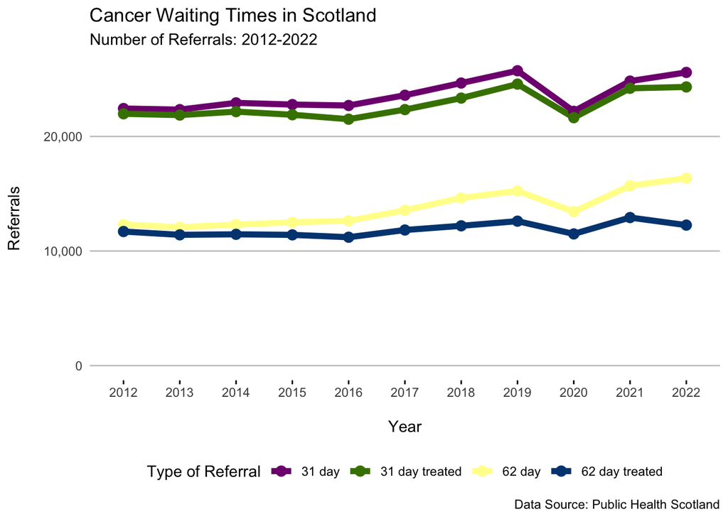

The trend is for increasing numbers of referrals being made. Of concern is the between 2021 and 2022 the gap between those referred and those treated within the target windows of time is at its largest. It is likely that the referral system is still processing a lot of people who developed symptoms during the year COVID-19 started (2020) but did not seek or were not able to be referred. It’s possible that people are presenting with conditions at a more advanced stage of the disease and now need more complex diagnostic procedures taking longer to reach the right treatment?

**Suggestion:**

It seems that more resources need to be directed towards improving getting treatment underway to undo the immediate delays from COVID. If there are any administrative processes that could be hastened or improvements in information/ communication that would be helpful for reducing the wait for patients.

### Are Cancer Waiting Time targets being met?

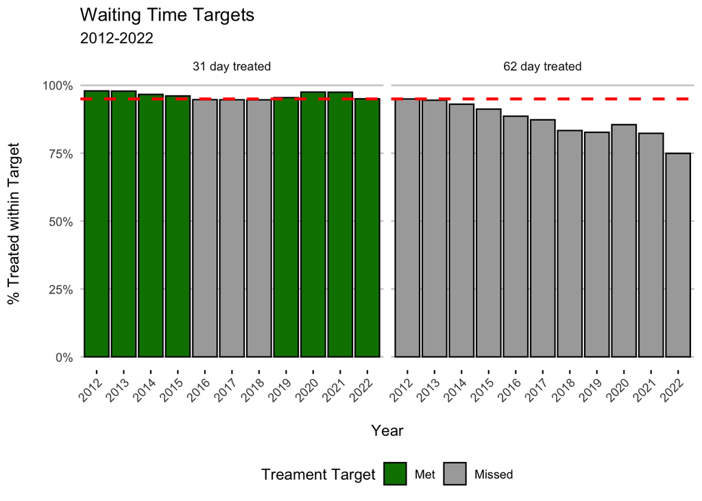

The dashed red line indicates the 95% target.

- 31 Day targets are being met.
- 62 Day targets are being missed.

There seems to be a chronic problem achieving the 62 day target as it has not been achieved even as far back as 2012 though other reports indicate it was achieved in 2011. The target must have been considered achievable when it was drawn up. What has changed?

The gap is widening as the years go by except for a brief improvement in 2020 the year COVID-10 started. If nothing tried so far has worked then this maybe needs a major rethink about how services are allocated and delivered.

The 31 day target was achieved in 2022 but barely scraped pass on 95.04%.  
**The 31 day target is also at high risk of being missed in 2023** and being October 2023 at time of writing, little time to put new measures in place.

**Suggestion**

Set up a focus group to review what’s been tried already and reasons for failure. It is noted that the NHS in England too is experiencing similar missed targets. There they are making adjustments to the reporting process”…following a consultation on the cancer waiting times standards…” [Changes to Cancer Waiting Times standards and Official Statistics](https://www.england.nhs.uk/statistics/statistical-work-areas/cancer-waiting-times/). They appear to be about to break categories down into greater detail in the data.

## Assumptions

- NRS use “.” in some columns - I’m assuming they just mean not available. It’s in things like columns for COVID in year 1994 etc. Or changes in what’s recorded.